# Video Game Sales - Can we Predict the Future?

Orel Mizrahi

# Project Description

My project is going to be an analysis of video game sales data, where I will be attempting to find predictors of total global sales. The data set I'm using is called "Video Game Sales and Ratings" and can be found here: https://www.kaggle.com/datasets/thedevastator/video-game-sales-and-ratings.

# Guiding Questions

There is a lot of useful data in this dataset, and with my project, I wanted to answer two questions

1. **Do Critic and User scores of a game predict sales?**
2. **Which of the two predicts sales more closely?**

But after my analysis of those questions, I also decided to explore a third possibility.

3. **Can ratings predict video game sales?**.

# Why does this matter?

I believe these questions have critical real-world applications and can affect game creation and marketing. For example, If it is found that games rated E for Everyone significantly outperform games rated M for Mature, it would stand to reason that game publishers would create more games rated E to give their game the best shot at doing well financially. Therefore, knowing the relationship between scores, ratings, and sales can change the decision-making for developers and alter the types of games that get created and released.

```python
import pandas as pd
import numpy as np
import matplotlib.pyplot as plt
from google.colab import drive
drive.mount('/content/drive')
%cd /content/drive/My Drive
```

```
/content/drive/My Drive
```

# Pre- Cleaning Visualization

```python
df = pd.read_csv("Video_Games.csv")
df.head()
```

|  | index | Name | Platform | Year_of_Release | Genre | Publisher | NA_Sales | EU_Sales | JP_Sales | Other_Sales | Global_Sales | Critic_Score | Critic_Count | User_Score | User_Count | Developer | Rating |
| --- | --- | --- | --- | --- | --- | --- | --- | --- | --- | --- | --- | --- | --- | --- | --- | --- | --- |
| 0 | 0 | Wii Sports | Wii | 2006.0 | Sports | Nintendo | 41.36 | 28.96 | 3.77 | 8.45 | 82.53 | 76.0 | 51.0 | 8 | 322.0 | Nintendo | E |
| 1 | 1 | Super Mario Bros. | NES | 1985.0 | Platform | Nintendo | 29.08 | 3.58 | 6.81 | 0.77 | 40.24 | NaN | NaN | NaN | NaN | NaN | NaN |
| 2 | 2 | Mario Kart Wii | Wii | 2008.0 | Racing | Nintendo | 15.68 | 12.76 | 3.79 | 3.29 | 35.52 | 82.0 | 73.0 | 8.3 | 709.0 | Nintendo | E |
| 3 | 3 | Wii Sports Resort | Wii | 2009.0 | Sports | Nintendo | 15.61 | 10.93 | 3.28 | 2.95 | 32.77 | 80.0 | 73.0 | 8 | 192.0 | Nintendo | E |
| 4 | 4 | Pokemon Red/Pokemon Blue | GB | 1996.0 | Role-Playing | Nintendo | 11.27 | 8.89 | 10.22 | 1.00 | 31.37 | NaN | NaN | NaN | NaN | NaN | NaN |

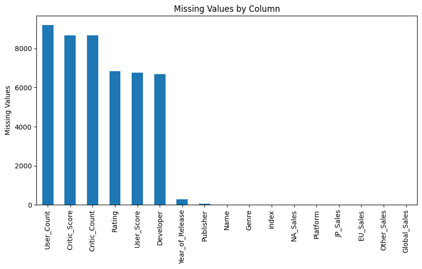

```python
df.isna().sum().sort_values(ascending=False).plot(
    kind="bar",
    figsize=(10,5)
)

plt.title("Missing Values by Column")
plt.ylabel("Missing Values")
plt.show()
```

It's good to note what information and how much of it is missing and use that knowledge to make more informed decisions when analyzing later on.

# Getting Data Ready

```python
critic_na = (df[df["Critic_Score"].isna()])
critic_na.describe()
```

|  | index | Year_of_Release | NA_Sales | EU_Sales | JP_Sales | Other_Sales | Global_Sales | Critic_Score | Critic_Count | User_Count |
| --- | --- | --- | --- | --- | --- | --- | --- | --- | --- | --- |
| count | 8668.000000 | 8552.000000 | 8668.000000 | 8668.000000 | 8668.000000 | 8668.000000 | 8668.000000 | 0.0 | 0.0 | 584.000000 |
| mean | 9575.670166 | 2005.811740 | 0.180087 | 0.085750 | 0.099639 | 0.023726 | 0.389432 | NaN | NaN | 24.863014 |
| std | 4774.981125 | 7.058611 | 0.715346 | 0.321349 | 0.343902 | 0.088725 | 1.222771 | NaN | NaN | 70.008148 |
| min | 1.000000 | 1980.000000 | 0.000000 | 0.000000 | 0.000000 | 0.000000 | 0.010000 | NaN | NaN | 4.000000 |
| 25% | 5690.750000 | 2001.000000 | 0.000000 | 0.000000 | 0.000000 | 0.000000 | 0.040000 | NaN | NaN | 6.000000 |
| 50% | 10081.500000 | 2008.000000 | 0.020000 | 0.000000 | 0.000000 | 0.000000 | 0.120000 | NaN | NaN | 9.000000 |
| 75% | 13814.250000 | 2011.000000 | 0.140000 | 0.050000 | 0.060000 | 0.020000 | 0.330000 | NaN | NaN | 18.000000 |
| max | 16927.000000 | 2020.000000 | 29.080000 | 10.950000 | 10.220000 | 2.740000 | 40.240000 | NaN | NaN | 1273.000000 |

It seems I have 8668 entries where a critic score is missing

I will remove entries with NaN to clear out empty data that will hinder my ability to perform an analysis. I then check the new dataframe for incorrect data types that I need to fix.

```python
df_clean = df.dropna()
df_analysis = df_clean[['Global_Sales', 'Critic_Score', 'User_Score', 'Rating']].copy()
df_clean.info()
```

```
<class 'pandas.core.frame.DataFrame'>
Index: 6938 entries, 0 to 16926
Data columns (total 17 columns):
 #   Column           Non-Null Count  Dtype
---  ------           --------------  -----
 0   index            6938 non-null   int64
 1   Name             6938 non-null   object
 2   Platform         6938 non-null   object
 3   Year_of_Release  6938 non-null   float64
 4   Genre            6938 non-null   object
 5   Publisher        6938 non-null   object
 6   NA_Sales         6938 non-null   float64
 7   EU_Sales         6938 non-null   float64
 8   JP_Sales         6938 non-null   float64
 9   Other_Sales      6938 non-null   float64
 10  Global_Sales     6938 non-null   float64
 11  Critic_Score     6938 non-null   float64
 12  Critic_Count     6938 non-null   float64
 13  User_Score       6938 non-null   object
 14  User_Count       6938 non-null   float64
 15  Developer        6938 non-null   object
 16  Rating           6938 non-null   object
dtypes: float64(9), int64(1), object(7)
memory usage: 975.7+ KB
```

In this case, it seems that the user score is being stored as an object, but I need to change it to allow further analysis.

```python
# Fixing the User_Score so it's numeric rather than an object

df_analysis["User_Score"] = pd.to_numeric(
    df_analysis["User_Score"],
    errors="coerce"
)

# Remove the rows that resulted in a NaN
df_analysis = df_analysis.dropna().copy()

# Getting rid of TBD data manually
df_analysis = df_analysis[df_analysis['Global_Sales'] >= 0.13]

# Shifting the user score decimal so it's aligned with the critic score
df_analysis["User_Score"] = df_analysis["User_Score"] * 10


df_analysis.info()
df_analysis.describe()
```

```
<class 'pandas.core.frame.DataFrame'>
Index: 5068 entries, 0 to 16926
Data columns (total 4 columns):
 #   Column        Non-Null Count  Dtype
---  ------        --------------  -----
 0   Global_Sales  5068 non-null   float64
 1   Critic_Score  5068 non-null   float64
 2   User_Score    5068 non-null   float64
 3   Rating        5068 non-null   object
dtypes: float64(3), object(1)
memory usage: 198.0+ KB
```

|  | Global_Sales | Critic_Score | User_Score |
| --- | --- | --- | --- |
| count | 5068.000000 | 5068.000000 | 5068.000000 |
| mean | 1.052581 | 72.248421 | 72.802881 |
| std | 2.240740 | 13.099732 | 13.539977 |
| min | 0.130000 | 19.000000 | 5.000000 |
| 25% | 0.250000 | 64.000000 | 66.000000 |
| 50% | 0.500000 | 74.000000 | 76.000000 |
| 75% | 1.040000 | 82.000000 | 83.000000 |
| max | 82.530000 | 98.000000 | 96.000000 |

After all the cleaning, I have a usable dataset with a little over 5,000 entries

# Analyzing Scores vs Sales

Now that all the data is cleaned up, I can start with the analysis. The first thing I'm going to do is make a graph plotting the scores given vs their global sales. I'm splitting this up into Critic vs User and putting them side by side to help visualize a difference and also answer my second question: Which of the two more closely predicts sales?

Two choices I made that I wanted to justify were the lines "axes[0].set_xlim(0, 100)" and "axes[0].set_yscale("log")". The easier to explain was setting the x-axis from 0 - 100 to standardize the view for both graphs, as they appeared different by default. The other change was using the log scale. For both of these graphs, there were outliers that heavily skewed the graphs, making it difficult to read and gain insight from. I had the choice to limit the y-axis and exclude some data or use a log view. I chose to use the log view as I felt excluding data would taint my analysis, although as I found out later on, my choice had its own consequences.

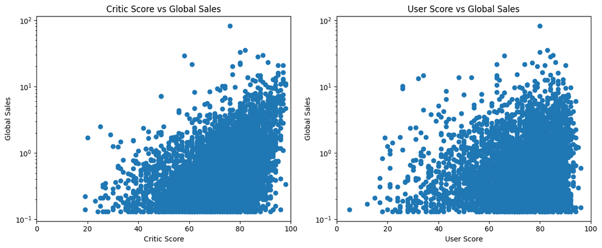

```python
fig, axes = plt.subplots(1, 2, figsize=(12, 5))

# Critic Score vs Sales
axes[0].scatter(
    df_analysis["Critic_Score"],
    df_analysis["Global_Sales"]
)

axes[0].set_title("Critic Score vs Global Sales")
axes[0].set_xlabel("Critic Score")
axes[0].set_ylabel("Global Sales")
axes[0].set_xlim(0, 100)
axes[0].set_yscale("log")


# User Score vs Sales
axes[1].scatter(
    df_analysis["User_Score"],
    df_analysis["Global_Sales"]
)

axes[1].set_title("User Score vs Global Sales")
axes[1].set_xlabel("User Score")
axes[1].set_ylabel("Global Sales")
axes[1].set_xlim(0, 100)
axes[1].set_yscale("log")

plt.tight_layout()
plt.show()
```

These are the graphs of critic and user scores vs global sales data. Upon looking at the graphs, they are incredibly similar, and both show a positive correlation between scores and global sales data. But based on the graphs, something I notice is that it seems the critics are more comfortable giving scores that creep near the 100 territory while the users avoid it, even when (based on the sales data) it is a good game.

### Correlation Matrix

While I have my graph, I wanted to get the numbers from a matrix to see if the graph accurately displayed the data and if my analysis was correct.

```python
# Making a matrix showing sales vs rating scores

df_analysis[
    ['Global_Sales', 'Critic_Score', 'User_Score']
].corr()
```

|  | Global_Sales | Critic_Score | User_Score |
| --- | --- | --- | --- |
| Global_Sales | 1.000000 | 0.239565 | 0.085676 |
| Critic_Score | 0.239565 | 1.000000 | 0.544709 |
| User_Score | 0.085676 | 0.544709 | 1.000000 |

After inserting the correlation matrix, it seems I was incorrect. In contrast to the graph data, it appears that the numbers show that the correlation between score and sales is low. The critic score does predict better than the user score (which is very close to 0), but is still low at 0.239. This is very insightful as it shows that graphs can be misleading. First, my choice to use a log graph affected the presentation, and based on my data, it seems that low scores predict low sales, but high scores can predict anything, which is an incredibly important distinction to make.

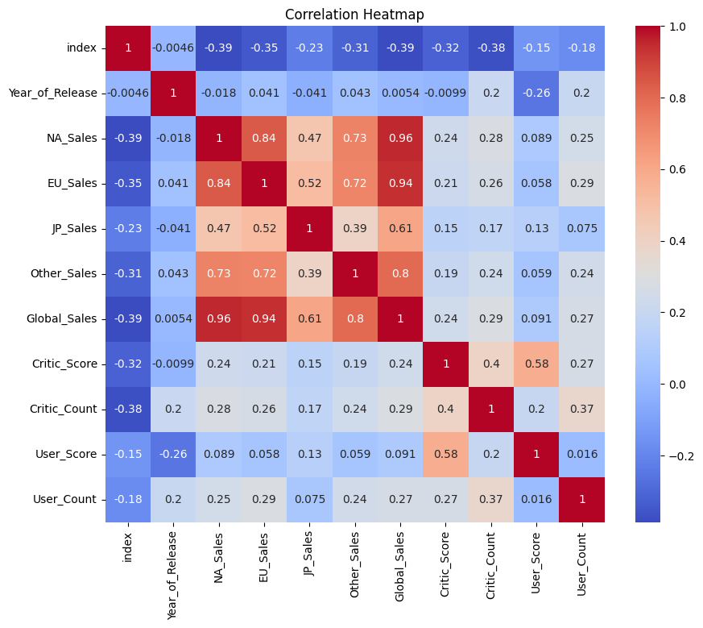

```python
import seaborn as sns
numeric_df = df_clean.copy()

# Changing the User_Score type to show on the heatmap
numeric_df["User_Score"] = pd.to_numeric(
    numeric_df["User_Score"],
    errors="coerce"
)

numeric_df = numeric_df.select_dtypes(include=np.number)

plt.figure(figsize=(10,8))

sns.heatmap(
    numeric_df.corr(),
    annot=True,
    cmap="coolwarm"
)

plt.title("Correlation Heatmap")
plt.show()
```

For visualization, here is a heatmap with the relationships between all categories. Something to note is that the highest correlations are the sales categories with the global and other countries which makes sense as they make up the global sales number. Another thing to note is that some of the strong(er) correlations are in the zone of critic to user score and critic score to sales.

This heatmap further shows the information that was obtained from the correlation matrix, that our critic score to sales correlation is 0.239, while the user score to sales correlation is shown to be 0.091.

# Analyzing Ratings

After checking the correlation between critic/user score's to sales, I wanted to see if there was any relationship between the ratings data and sales. My hypothesis going in is that the more restrictive the rating, the less the average sales are going to be. For example, I suspect the highest average sales will be within the E for everyone category since it is the most encompassing group.

First, I separate the rating data and make a bar graph to illustrate it.

```python
rating_means = df_analysis.groupby("Rating")[
    "Global_Sales"
].mean()

rating_means.head()
```

| Rating | Global_Sales |
| --- | --- |
| AO | 1.950000 |
| E | 1.223474 |
| E10+ | 0.797226 |
| K-A | 1.920000 |
| M | 1.324627 |

**dtype:** float64

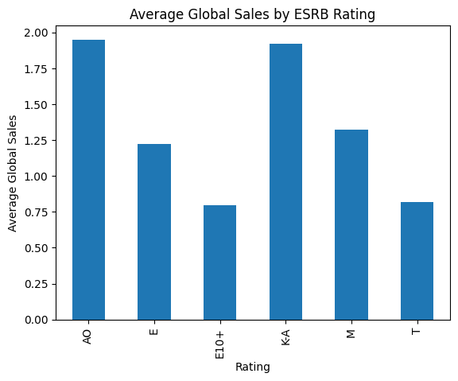

```python
rating_means.plot(kind="bar")

plt.ylabel("Average Global Sales")
plt.title("Average Global Sales by ESRB Rating")

plt.show()
```

When I saw this originally, it seemed very odd to me that games with ratings like Adults Only would be wildly outselling games that are rated for Everyone. Because of this, I added another graph and table illustrating the # of values each rating has to see if the amount of data I have was affecting the graph.

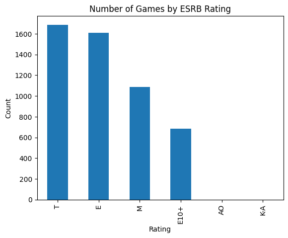

| Rating | count |
| --- | --- |
| T | 1687 |
| E | 1609 |
| M | 1085 |
| E10+ | 685 |
| AO | 1 |
| K-A | 1 |

**dtype:** int64

```python
df_analysis["Rating"].value_counts().plot(kind="bar")

plt.title("Number of Games by ESRB Rating")
plt.ylabel("Count")

plt.show()
df_analysis["Rating"].value_counts()
```

This made the previous graph make more sense, seeing that AO and K-A only had 1 entry each, which wildly skewed their respective data. Therefore, I made another graph removing those ratings.

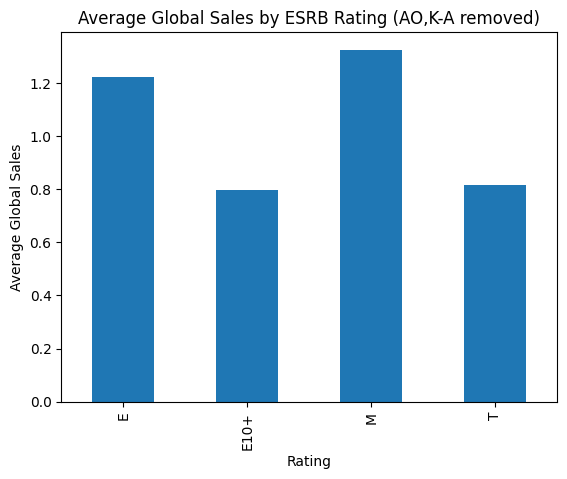

```python
rating_means = df_analysis[
    ~df_analysis["Rating"].isin(["AO", "K-A"])
].groupby("Rating")["Global_Sales"].mean()

rating_means.plot(kind="bar")

plt.ylabel("Average Global Sales")
plt.title("Average Global Sales by ESRB Rating (AO,K-A removed)")

plt.show()
```

This graph depicts a more accurate picture of the data. But this still conflicted with my hypothesis that ratings such as T and M would have lower sales due to the limited audience they would be selling to. It seems I was incorrect, and based on an observation of this graph, it would seem that ratings of T and E10+ result in overall lower sales.

# Linear Regression

I wanted to run a regression to get solid data on the predictions I made previously. I decided linear regression best fits my task to try to use the three variables I've been looking at to predict the sales outcome.

```python
from sklearn.model_selection import train_test_split
from sklearn.linear_model import LinearRegression
from sklearn.metrics import mean_squared_error, r2_score

df_model = df_analysis.copy()

df_model = pd.get_dummies(df_model, columns=["Rating"], drop_first=True)
x = df_model.drop("Global_Sales", axis=1)
y = np.log1p(df_model["Global_Sales"])
x_train, x_test, y_train, y_test = train_test_split(
    x, y,
    test_size=0.2,
    random_state=42
)

model = LinearRegression()
model.fit(x_train, y_train)
y_pred = model.predict(x_test)
print("R^2 Score:", r2_score(y_test, y_pred))
print("RMSE:", np.sqrt(mean_squared_error(y_test, y_pred)))
```

```
R^2 Score: 0.19153106729401193
RMSE: 0.4433323978390104
```

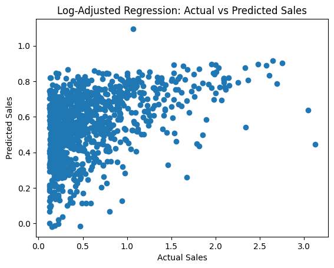

```python
plt.scatter(y_test, y_pred)
plt.xlabel("Actual Sales")
plt.ylabel("Predicted Sales")
plt.title("Log-Adjusted Regression: Actual vs Predicted Sales")
plt.show()
```

This model was trained to predict global sales using critic score, user score, and ESRB rating. The model achieved an R² of 0.19, indicating weak predictive power. This suggests that while there is a slight relationship between review scores and sales, they are insufficient as strong predictors on their own. (A log transformation of sales was applied to address extreme skews in the data)

# Insight and Future Goals

Going back to my original questions, I now have my answers. Overall, it seems that critics **are better** at predicting sales compared to users, but that prediction has a **low correlation** of 0.239. In the data, low scores are good predictors of low sales, **but high scores are not necessarily good predictors of high sales**. My final question was whether or not ratings could predict video game sales. After my analysis, it seems that ratings **do not** predict sales.

To further evaluate this relationship, I created a linear regression model using critic score, user score, and ESRB rating to predict global sales. Because the sales data was heavily skewed by extreme outliers, I applied a logarithmic transformation to the sales values before training the model. The regression model achieved an (R^2) score of approximately 0.19, meaning the variables in the model explained about 19% of the variation in global sales. This indicates that review scores and ratings do have some predictive value, but they are not strong predictors on their own.

The choices I made regarding presentation and the presence of extremes in the data exaggerated the trends in the data and led me to make false assumptions. In the future, my goal is to make better decisions about data visualizations to avoid making the same mistake again

Going forward, I think a more comprehensive dataset is needed. This is because after cleaning the data, sometimes I only had 1 entry for a variable to work with, and the majority of my data had NaNs, which removed data such as retro games that more often had missing data, rendering my analysis incomplete.